# DPA Homework2

Avinash Vellineni

### Problem 2.1

```r
rm(list=ls())
```

```r
library("MASS")
library(tidyverse)
library(psych)
library("moments")
library(caret)
library(corrplot)
library(rpart)
library(rpart.plot)
library(ROCR)
library("e1071")
```

Loading Boston dataset

```r
setwd("E:/IIT CHICAGO STUDIES/IIT Chicago semester 2/Data Prep and Analysis/Assignment/Assignment2")
head(Boston)
```

|  | crim | zn | indus | chas | nox | rm | age | dis | rad | tax | ptratio | black | lstat | medv |
| --- | --- | --- | --- | --- | --- | --- | --- | --- | --- | --- | --- | --- | --- | --- |
| 1 | 0.00632 | 18 | 2.31 | 0 | 0.538 | 6.575 | 65.2 | 4.0900 | 1 | 296 | 15.3 | 396.90 | 4.98 | 24.0 |
| 2 | 0.02731 | 0 | 7.07 | 0 | 0.469 | 6.421 | 78.9 | 4.9671 | 2 | 242 | 17.8 | 396.90 | 9.14 | 21.6 |
| 3 | 0.02729 | 0 | 7.07 | 0 | 0.469 | 7.185 | 61.1 | 4.9671 | 2 | 242 | 17.8 | 392.83 | 4.03 | 34.7 |
| 4 | 0.03237 | 0 | 2.18 | 0 | 0.458 | 6.998 | 45.8 | 6.0622 | 3 | 222 | 18.7 | 394.63 | 2.94 | 33.4 |
| 5 | 0.06905 | 0 | 2.18 | 0 | 0.458 | 7.147 | 54.2 | 6.0622 | 3 | 222 | 18.7 | 396.90 | 5.33 | 36.2 |
| 6 | 0.02985 | 0 | 2.18 | 0 | 0.458 | 6.430 | 58.7 | 6.0622 | 3 | 222 | 18.7 | 394.12 | 5.21 | 28.7 |

```r
dim(Boston)
```

```
[1] 506  14
```

```r
str(Boston)
```

```
'data.frame':   506 obs. of  14 variables:
 $ crim   : num  0.00632 0.02731 0.02729 0.03237 0.06905 ...
 $ zn     : num  18 0 0 0 0 0 12.5 12.5 12.5 12.5 ...
 $ indus  : num  2.31 7.07 7.07 2.18 2.18 2.18 7.87 7.87 7.87 7.87 ...
 $ chas   : int  0 0 0 0 0 0 0 0 0 0 ...
 $ nox    : num  0.538 0.469 0.469 0.458 0.458 0.458 0.524 0.524 0.524 0.524 ...
 $ rm     : num  6.58 6.42 7.18 7 7.15 ...
 $ age    : num  65.2 78.9 61.1 45.8 54.2 58.7 66.6 96.1 100 85.9 ...
 $ dis    : num  4.09 4.97 4.97 6.06 6.06 ...
 $ rad    : int  1 2 2 3 3 3 5 5 5 5 ...
 $ tax    : num  296 242 242 222 222 222 311 311 311 311 ...
 $ ptratio: num  15.3 17.8 17.8 18.7 18.7 18.7 15.2 15.2 15.2 15.2 ...
 $ black  : num  397 397 393 395 397 ...
 $ lstat  : num  4.98 9.14 4.03 2.94 5.33 ...
 $ medv   : num  24 21.6 34.7 33.4 36.2 28.7 22.9 27.1 16.5 18.9 ...
```

Checking correlation among predictors and features.

```r
Str_corr <- cor(cbind(Boston$crim,Boston$zn,Boston$indus,Boston$chas,Boston$nox,Boston$rm,Boston$age,Boston$dis,Boston$rad,Boston$tax,Boston$ptratio,Boston$black,Boston$lstat,Boston$medv))
Str_corr[,14]
```

```
 [1] -0.3883046  0.3604453 -0.4837252  0.1752602 -0.4273208  0.6953599 -0.3769546  0.2499287
 [9] -0.3816262 -0.4685359 -0.5077867  0.3334608 -0.7376627  1.0000000
```

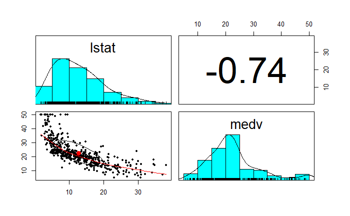

```r
pairs.panels(Boston[,c(13,14)])
```

Linear Model

```r
Linear_model <- lm(medv~lstat,data = Boston)
summary(Linear_model)
```

```
Call:
lm(formula = medv ~ lstat, data = Boston)

Residuals:
    Min      1Q  Median      3Q     Max
-15.168  -3.990  -1.318   2.034  24.500

Coefficients:
            Estimate Std. Error t value Pr(>|t|)
(Intercept) 34.55384    0.56263   61.41   <2e-16 ***
lstat       -0.95005    0.03873  -24.53   <2e-16 ***
---
Signif. codes:  0 ‘***’ 0.001 ‘**’ 0.01 ‘*’ 0.05 ‘.’ 0.1 ‘ ’ 1

Residual standard error: 6.216 on 504 degrees of freedom
Multiple R-squared:  0.5441,    Adjusted R-squared:  0.5432
F-statistic: 601.6 on 1 and 504 DF,  p-value: < 2.2e-16
```

```r
anova(Linear_model)
```

```
Analysis of Variance Table

Response: medv
           Df Sum Sq Mean Sq F value    Pr(>F)
lstat       1  23244 23243.9  601.62 < 2.2e-16 ***
Residuals 504  19472    38.6
---
Signif. codes:  0 ‘***’ 0.001 ‘**’ 0.01 ‘*’ 0.05 ‘.’ 0.1 ‘ ’ 1
```

Fitted vs The residual plot

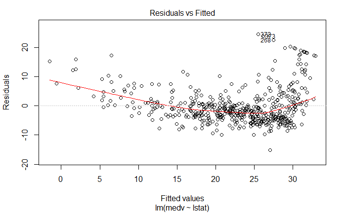

```r
plot(Linear_model,1)
```

From the fitted values vs the residual plot we can see a slightly U shaped line (i.e)

The residuals for the small and high values are positive while the middle values have residuals in negative value.

This shows that that there is some non-linearity in the data. Note: the red line in the graph is not a perfect straight line.

Correlation plot between the response and the predictor.

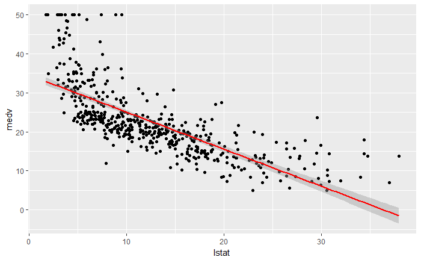

```r
ggplot(Boston, aes(x = lstat, y = medv)) +
  geom_point() +
  stat_smooth(method = "lm", col = "red")
```

From the predictor vs response plot we can infer that as the medv attribute increases lstat attribute decreases.

Histogram of the residual plot

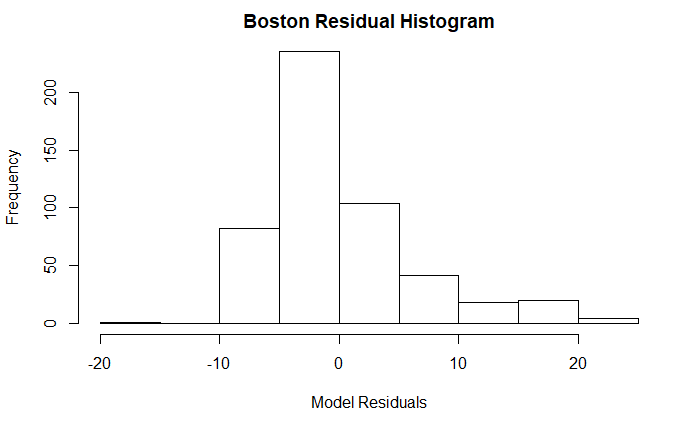

```r
hist(Linear_model$residuals, xlab = "Model Residuals",
     main="Boston Residual Histogram")
```

```r
skewness(Linear_model$residuals)
```

```
[1] 1.448435
```

```r
names(Boston)
```

```
 [1] "crim"    "zn"      "indus"   "chas"    "nox"     "rm"      "age"     "dis"     "rad"
[10] "tax"     "ptratio" "black"   "lstat"   "medv"
```

Prediction intervals

```r
predict_values <- predict(Linear_model,data.frame(lstat = c(5, 10, 15)), interval="prediction")
predict_values
```

```
       fit       lwr      upr
1 29.80359 17.565675 42.04151
2 25.05335 12.827626 37.27907
3 20.30310  8.077742 32.52846
```

```r
summary(predict_values)
```

```
      fit             lwr              upr
 Min.   :20.30   Min.   : 8.078   Min.   :32.53
 1st Qu.:22.68   1st Qu.:10.453   1st Qu.:34.90
 Median :25.05   Median :12.828   Median :37.28
 Mean   :25.05   Mean   :12.824   Mean   :37.28
 3rd Qu.:27.43   3rd Qu.:15.197   3rd Qu.:39.66
 Max.   :29.80   Max.   :17.566   Max.   :42.04
```

Confidence intervals

```r
confi_value <- predict(Linear_model,data.frame(lstat = c(5, 10, 15)), interval="confidence")
confi_value
```

```
       fit      lwr      upr
1 29.80359 29.00741 30.59978
2 25.05335 24.47413 25.63256
3 20.30310 19.73159 20.87461
```

Fitvalues of the confidence and the prediction values are the same. For lstat value of five.

The fit value of prediction interval is 29.80359 and the range of values are [17.565675,42.04151].

The fit value of Confidence interval is 29.80359 and the range of values are [29.00741,30.59978].

From the results we can see that confidence interval has a tight bound around the fit values than the prediction interval.

Multilinear regression

```r
lstat_2<-Boston$lstat*Boston$lstat
New_Linear_model <- lm(medv~lstat+lstat_2,data = Boston)
summary(New_Linear_model)
```

```
Call:
lm(formula = medv ~ lstat + lstat_2, data = Boston)

Residuals:
     Min       1Q   Median       3Q      Max
-15.2834  -3.8313  -0.5295   2.3095  25.4148

Coefficients:
             Estimate Std. Error t value Pr(>|t|)
(Intercept) 42.862007   0.872084   49.15   <2e-16 ***
lstat       -2.332821   0.123803  -18.84   <2e-16 ***
lstat_2      0.043547   0.003745   11.63   <2e-16 ***
---
Signif. codes:  0 ‘***’ 0.001 ‘**’ 0.01 ‘*’ 0.05 ‘.’ 0.1 ‘ ’ 1

Residual standard error: 5.524 on 503 degrees of freedom
Multiple R-squared:  0.6407,    Adjusted R-squared:  0.6393
F-statistic: 448.5 on 2 and 503 DF,  p-value: < 2.2e-16
```

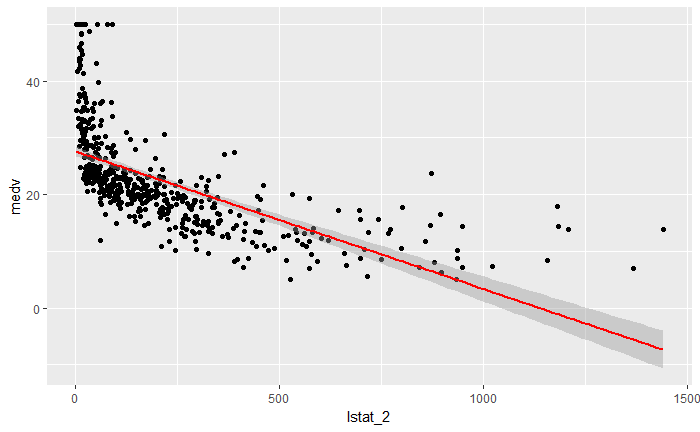

```r
ggplot(Boston, aes(x = lstat_2, y = medv)) +
  geom_point() +
  stat_smooth(method = "lm", col = "red")
```

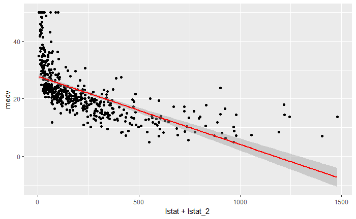

```r
ggplot(Boston, aes(x = lstat+lstat_2, y = medv)) +
  geom_point() +
  stat_smooth(method = "lm", col = "red")
```

Residual vs fittedvalues plot

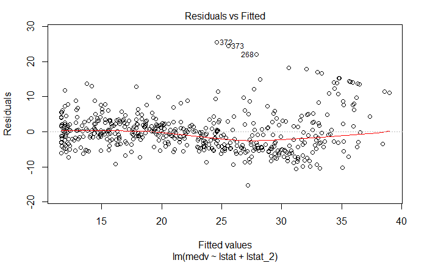

```r
plot(New_Linear_model,1)
```

R2 for the non-linear fit is higher than the linear fit model.

The non-linear model has captured more variance than the linear model.

Now the line is almost close to linear data is evenly shared on the poisitive and negative side of the residuals.

```r
anova(Linear_model,New_Linear_model)
```

```
Analysis of Variance Table

Model 1: medv ~ lstat
Model 2: medv ~ lstat + lstat_2
  Res.Df   RSS Df Sum of Sq     F    Pr(>F)
1    504 19472
2    503 15347  1    4125.1 135.2 < 2.2e-16 ***
---
Signif. codes:  0 ‘***’ 0.001 ‘**’ 0.01 ‘*’ 0.05 ‘.’ 0.1 ‘ ’ 1
```

From the anova results we can see that the model1 has higher RSS value (i.e) the data points lie far away from the model1 than model2.

### Problem 2.2

Loading the Abalone Dataset

```r
url_abalone <- "https://archive.ics.uci.edu/ml/machine-learning-databases/abalone/abalone.data"
df_abalone <- read.csv(url_abalone,sep = ",",header = F)
head(df_abalone)
```

|  | V1 | V2 | V3 | V4 | V5 | V6 | V7 | V8 | V9 |
| --- | --- | --- | --- | --- | --- | --- | --- | --- | --- |
| 1 | M | 0.455 | 0.365 | 0.095 | 0.5140 | 0.2245 | 0.1010 | 0.150 | 15 |
| 2 | M | 0.350 | 0.265 | 0.090 | 0.2255 | 0.0995 | 0.0485 | 0.070 | 7 |
| 3 | F | 0.530 | 0.420 | 0.135 | 0.6770 | 0.2565 | 0.1415 | 0.210 | 9 |
| 4 | M | 0.440 | 0.365 | 0.125 | 0.5160 | 0.2155 | 0.1140 | 0.155 | 10 |
| 5 | I | 0.330 | 0.255 | 0.080 | 0.2050 | 0.0895 | 0.0395 | 0.055 | 7 |
| 6 | I | 0.425 | 0.300 | 0.095 | 0.3515 | 0.1410 | 0.0775 | 0.120 | 8 |

```r
names(df_abalone) <- c("Sex","Length","Diameter","Height","Whole_weight","Shucked_weight","Viscera_weight","Shell_weight","Rings")
head(df_abalone)
```

|  | Sex | Length | Diameter | Height | Whole_weight | Shucked_weight | Viscera_weight | Shell_weight | Rings |
| --- | --- | --- | --- | --- | --- | --- | --- | --- | --- |
| 1 | M | 0.455 | 0.365 | 0.095 | 0.5140 | 0.2245 | 0.1010 | 0.150 | 15 |
| 2 | M | 0.350 | 0.265 | 0.090 | 0.2255 | 0.0995 | 0.0485 | 0.070 | 7 |
| 3 | F | 0.530 | 0.420 | 0.135 | 0.6770 | 0.2565 | 0.1415 | 0.210 | 9 |
| 4 | M | 0.440 | 0.365 | 0.125 | 0.5160 | 0.2155 | 0.1140 | 0.155 | 10 |
| 5 | I | 0.330 | 0.255 | 0.080 | 0.2050 | 0.0895 | 0.0395 | 0.055 | 7 |
| 6 | I | 0.425 | 0.300 | 0.095 | 0.3515 | 0.1410 | 0.0775 | 0.120 | 8 |

Removal of Observations of Infant category.

```r
sum(df_abalone$Sex == "I")
```

```
[1] 1342
```

```r
rm_index = which(df_abalone$Sex == "I")
Updated_df_abalone <- df_abalone[-rm_index,]
Updated_df_abalone$Sex <- factor(Updated_df_abalone$Sex, labels = c("M","F"))
head(Updated_df_abalone)
```

|  | Sex | Length | Diameter | Height | Whole_weight | Shucked_weight | Viscera_weight | Shell_weight | Rings |
| --- | --- | --- | --- | --- | --- | --- | --- | --- | --- |
| 1 | F | 0.455 | 0.365 | 0.095 | 0.5140 | 0.2245 | 0.1010 | 0.150 | 15 |
| 2 | F | 0.350 | 0.265 | 0.090 | 0.2255 | 0.0995 | 0.0485 | 0.070 | 7 |
| 3 | M | 0.530 | 0.420 | 0.135 | 0.6770 | 0.2565 | 0.1415 | 0.210 | 9 |
| 4 | F | 0.440 | 0.365 | 0.125 | 0.5160 | 0.2155 | 0.1140 | 0.155 | 10 |
| 7 | M | 0.530 | 0.415 | 0.150 | 0.7775 | 0.2370 | 0.1415 | 0.330 | 20 |
| 8 | M | 0.545 | 0.425 | 0.125 | 0.7680 | 0.2940 | 0.1495 | 0.260 | 16 |

```r
str(Updated_df_abalone)
```

```
'data.frame':   2835 obs. of  9 variables:
 $ Sex           : Factor w/ 2 levels "M","F": 2 2 1 2 1 1 2 1 1 2 ...
 $ Length        : num  0.455 0.35 0.53 0.44 0.53 0.545 0.475 0.55 0.525 0.43 ...
 $ Diameter      : num  0.365 0.265 0.42 0.365 0.415 0.425 0.37 0.44 0.38 0.35 ...
 $ Height        : num  0.095 0.09 0.135 0.125 0.15 0.125 0.125 0.15 0.14 0.11 ...
 $ Whole_weight  : num  0.514 0.226 0.677 0.516 0.777 ...
 $ Shucked_weight: num  0.2245 0.0995 0.2565 0.2155 0.237 ...
 $ Viscera_weight: num  0.101 0.0485 0.1415 0.114 0.1415 ...
 $ Shell_weight  : num  0.15 0.07 0.21 0.155 0.33 0.26 0.165 0.32 0.21 0.135 ...
 $ Rings         : int  15 7 9 10 20 16 9 19 14 10 ...
```

```r
part_train <- createDataPartition(Updated_df_abalone$Sex, p = 0.8,list = F)
train_ab <- Updated_df_abalone[part_train,]
test_ab <- Updated_df_abalone[-part_train,]
```

Logistic regression

```r
glm_ab <- glm(Sex~.,data = train_ab,family = binomial)
summary(glm_ab)
```

```
Call:
glm(formula = Sex ~ ., family = binomial, data = train_ab)

Deviance Residuals:
    Min       1Q   Median       3Q      Max
-1.8066  -1.2031   0.8676   1.1216   1.4860

Coefficients:
                Estimate Std. Error z value Pr(>|z|)
(Intercept)     2.738223   0.514527   5.322 1.03e-07 ***
Length         -0.358641   2.280990  -0.157  0.87506
Diameter       -6.924914   2.724285  -2.542  0.01102 *
Height         -2.076901   2.529372  -0.821  0.41158
Whole_weight   -0.024315   0.821665  -0.030  0.97639
Shucked_weight  2.960594   0.980361   3.020  0.00253 **
Viscera_weight -1.603716   1.420702  -1.129  0.25897
Shell_weight    0.124119   1.286057   0.097  0.92311
Rings           0.007614   0.017844   0.427  0.66959
---
Signif. codes:  0 ‘***’ 0.001 ‘**’ 0.01 ‘*’ 0.05 ‘.’ 0.1 ‘ ’ 1

(Dispersion parameter for binomial family taken to be 1)

    Null deviance: 3131.7  on 2268  degrees of freedom
Residual deviance: 3072.3  on 2260  degrees of freedom
AIC: 3090.3

Number of Fisher Scoring iterations: 4
```

Since the p value of Shucked_weight is very low compared to the other predictors followed by Distance feature they are significant predictors and should not be discarded.

```r
confi_ab <- predict(glm_ab,test_ab, interval="confidence")
head(confi_ab)
```

```
         1         13         30         31         35         41
 0.4731563  0.2363907  0.1852063 -0.1974432 -0.4063354  0.5175960
```

```r
summary(confi_ab)
```

```
   Min. 1st Qu.  Median    Mean 3rd Qu.    Max.
-1.3703 -0.0634  0.1172  0.1441  0.3184  1.8914
```

Yes, the confidence interval has zero within its range of values. If the modal coefficients are close to zero or the p value is hight > 5% usually then it will satisfy the null hypothesis. If the p value is less than 0.05 then the confidence interval will not contain the null hypothesis value.They are related to standard errors (i.e) how much the predicted values deviate from the actual values.

```r
response_glm <- predict(glm_ab,test_ab, type = "response")
predict_glm <- ifelse(response_glm > 0.5, "F", "M")
head(predict_glm)
```

```
  1  13  30  31  35  41
"F" "F" "F" "M" "M" "F"
```

```r
head(test_ab$Sex)
```

```
[1] F F F F M M
Levels: M F
```

```r
confusionMatrix(predict_glm, test_ab$Sex)
```

```
Levels are not in the same order for reference and data. Refactoring data to match.
```

```
Confusion Matrix and Statistics

          Reference
Prediction   M   F
         M  96  95
         F 165 210

               Accuracy : 0.5406
                 95% CI : (0.4986, 0.5823)
    No Information Rate : 0.5389
    P-Value [Acc > NIR] : 0.4836

                  Kappa : 0.0575
 Mcnemar's Test P-Value : 1.876e-05

            Sensitivity : 0.3678
            Specificity : 0.6885
         Pos Pred Value : 0.5026
         Neg Pred Value : 0.5600
             Prevalence : 0.4611
         Detection Rate : 0.1696
   Detection Prevalence : 0.3375
      Balanced Accuracy : 0.5282

       'Positive' Class : M
```

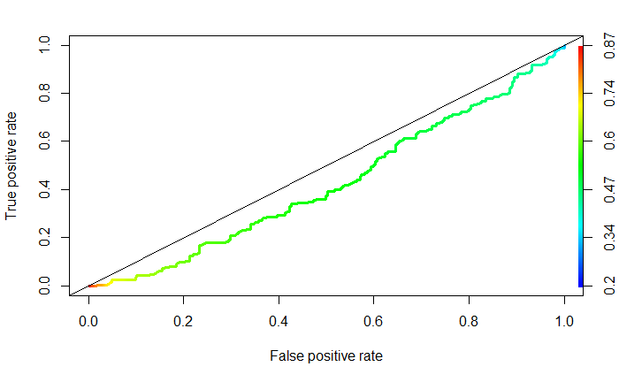

```r
pred.rocr <- predict(glm_ab, newdata=test_ab, type="response")
f.pred <- prediction(pred.rocr, test_ab$Sex)
f.perf <- performance(f.pred, "tpr", "fpr")
plot(f.perf, colorize=T, lwd=3)
abline(0,1)
```

```r
auc <- performance(f.pred, measure = "auc")
cat(paste("The area under curve (AUC) for this model is ", round(auc@y.values[[1]], 3)))
```

```
The area under curve (AUC) for this model is  0.424
```

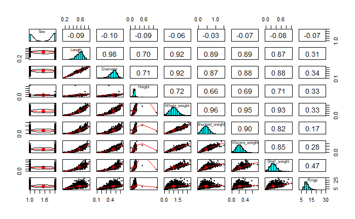

```r
pairs.panels(Updated_df_abalone)
```

rpart classifier

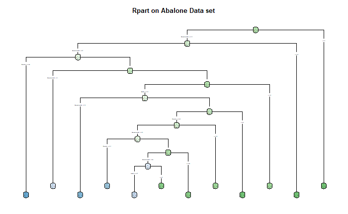

```r
roc_model <- rpart(Sex ~ ., method="class", data=train_ab)
rpart.plot(roc_model, extra=104, fallen.leaves = T, type=4, main="Rpart on Abalone Data set")
```

```r
summary(roc_model)
```

```
Call:
rpart(formula = Sex ~ ., data = train_ab, method = "class")
  n= 2269

          CP nsplit rel error   xerror       xstd
1 0.01306565      0 1.0000000 1.000000 0.02270022
2 0.01083493      6 0.9130019 1.027725 0.02273827
3 0.01000000     11 0.8518164 1.011472 0.02271778

Variable importance
      Diameter Shucked_weight         Length   Whole_weight Viscera_weight   Shell_weight
            20             20             17             17             13             11
        Height
             2

Node number 1: 2269 observations,    complexity param=0.01306565
  predicted class=F  expected loss=0.460996  P(node) =1
    class counts:  1046  1223
   probabilities: 0.461 0.539
  left son=2 (2157 obs) right son=3 (112 obs)
  Primary splits:
      Shucked_weight < 0.1105  to the right, improve=18.79479, (0 missing)
      Length         < 0.3575  to the right, improve=18.17715, (0 missing)
      Height         < 0.1025  to the right, improve=17.84331, (0 missing)
      Whole_weight   < 0.30775 to the right, improve=17.69621, (0 missing)
      Viscera_weight < 0.04575 to the right, improve=16.37571, (0 missing)
  Surrogate splits:
      Whole_weight   < 0.26575 to the right, agree=0.995, adj=0.902, (0 split)
      Shell_weight   < 0.08325 to the right, agree=0.992, adj=0.839, (0 split)
      Length         < 0.3725  to the right, agree=0.991, adj=0.821, (0 split)
      Viscera_weight < 0.05625 to the right, agree=0.991, adj=0.821, (0 split)
      Diameter       < 0.2825  to the right, agree=0.989, adj=0.786, (0 split)

Node number 2: 2157 observations,    complexity param=0.01306565
  predicted class=F  expected loss=0.4756606  P(node) =0.950639
    class counts:  1026  1131
   probabilities: 0.476 0.524
  left son=4 (2077 obs) right son=5 (80 obs)
  Primary splits:
      Shucked_weight < 0.87325 to the left,  improve=4.423484, (0 missing)
```

[output cut: 213 more lines]

```

Node number 1235: 272 observations
  predicted class=F  expected loss=0.3970588  P(node) =0.1198766
    class counts:   108   164
   probabilities: 0.397 0.603

Node number 2468: 240 observations
  predicted class=M  expected loss=0.4375  P(node) =0.1057735
    class counts:   135   105
   probabilities: 0.562 0.438

Node number 2469: 109 observations
  predicted class=F  expected loss=0.3944954  P(node) =0.04803878
    class counts:    43    66
   probabilities: 0.394 0.606
```

```r
predict_test_ab <- predict(roc_model, test_ab, type="class")
head(predict_test_ab)
```

```
 1 13 30 31 35 41
 F  F  F  M  M  M
Levels: M F
```

```r
head(test_ab$Sex)
```

```
[1] F F F F M M
Levels: M F
```

```r
cm_ab <- confusionMatrix(predict_test_ab, test_ab$Sex)
cm_ab
```

```
Confusion Matrix and Statistics

          Reference
Prediction   M   F
         M 122 121
         F 139 184

               Accuracy : 0.5406
                 95% CI : (0.4986, 0.5823)
    No Information Rate : 0.5389
    P-Value [Acc > NIR] : 0.4836

                  Kappa : 0.0711
 Mcnemar's Test P-Value : 0.2917

            Sensitivity : 0.4674
            Specificity : 0.6033
         Pos Pred Value : 0.5021
         Neg Pred Value : 0.5697
             Prevalence : 0.4611
         Detection Rate : 0.2155
   Detection Prevalence : 0.4293
      Balanced Accuracy : 0.5354

       'Positive' Class : M
```

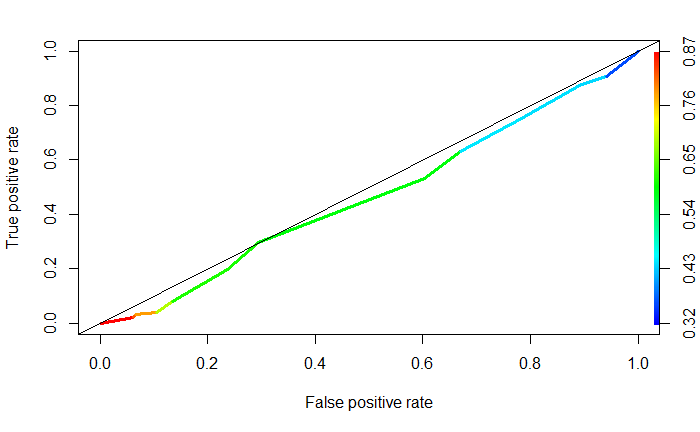

```r
pred.rocr1 <- predict(roc_model, newdata=test_ab, type="prob")[,2]
f.pred1 <- prediction(pred.rocr1, test_ab$Sex)
f.perf1 <- performance(f.pred1, "tpr", "fpr")
plot(f.perf1, colorize=T, lwd=3)
abline(0,1)
```

```r
auc1 <- performance(f.pred1, measure = "auc")
cat(paste("The area under curve (AUC) for this model is ", round(auc1@y.values[[1]], 3)))
```

```
The area under curve (AUC) for this model is  0.466
```

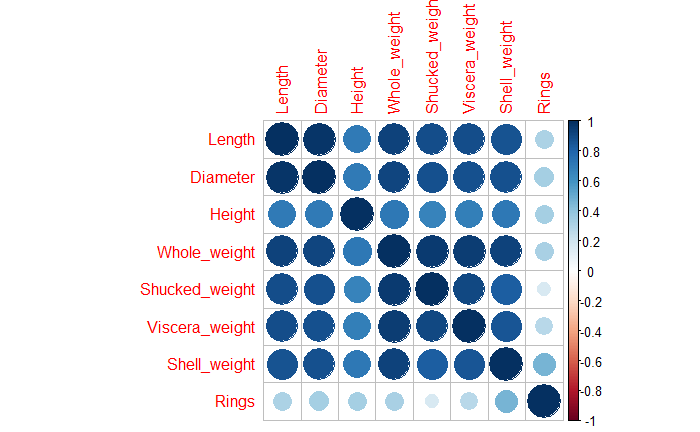

```r
cor_plot = cor(Updated_df_abalone[2:9])
corrplot(cor_plot)
```

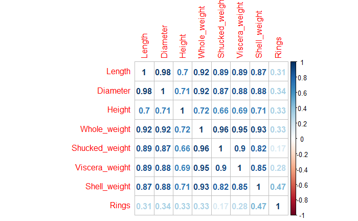

```r
corrplot(cor_plot, method="number")
```

Selecting predictors and using glm model

```r
glm_ab2 <- glm(Sex~Diameter+Shucked_weight,data = train_ab,family = binomial)
summary(glm_ab2)
```

```
Call:
glm(formula = Sex ~ Diameter + Shucked_weight, family = binomial,
    data = train_ab)

Deviance Residuals:
    Min       1Q   Median       3Q      Max
-1.8491  -1.2036   0.8677   1.1213   1.4705

Coefficients:
               Estimate Std. Error z value Pr(>|z|)
(Intercept)      2.8447     0.3773   7.539 4.73e-14 ***
Diameter        -8.3502     1.1759  -7.101 1.24e-12 ***
Shucked_weight   2.3768     0.4231   5.618 1.94e-08 ***
---
Signif. codes:  0 ‘***’ 0.001 ‘**’ 0.01 ‘*’ 0.05 ‘.’ 0.1 ‘ ’ 1

(Dispersion parameter for binomial family taken to be 1)

    Null deviance: 3131.7  on 2268  degrees of freedom
Residual deviance: 3075.8  on 2266  degrees of freedom
AIC: 3081.8

Number of Fisher Scoring iterations: 4
```

```r
confi_ab2 <- predict(glm_ab2,test_ab, interval="confidence")
summary(confi_ab2)
```

```
    Min.  1st Qu.   Median     Mean  3rd Qu.     Max.
-0.74595 -0.04868  0.10680  0.15080  0.31895  1.90584
```

```r
response_glm2 <- predict(glm_ab2,test_ab, type = "response")
predict_glm2 <- ifelse(response_glm2 > 0.5, "F", "M")
confusionMatrix(predict_glm2, test_ab$Sex)
```

```
Levels are not in the same order for reference and data. Refactoring data to match.
```

```
Confusion Matrix and Statistics

          Reference
Prediction   M   F
         M  93  95
         F 168 210

               Accuracy : 0.5353
                 95% CI : (0.4933, 0.577)
    No Information Rate : 0.5389
    P-Value [Acc > NIR] : 0.5839

                  Kappa : 0.0458
 Mcnemar's Test P-Value : 9.008e-06

            Sensitivity : 0.3563
            Specificity : 0.6885
         Pos Pred Value : 0.4947
         Neg Pred Value : 0.5556
             Prevalence : 0.4611
         Detection Rate : 0.1643
   Detection Prevalence : 0.3322
      Balanced Accuracy : 0.5224

       'Positive' Class : M
```

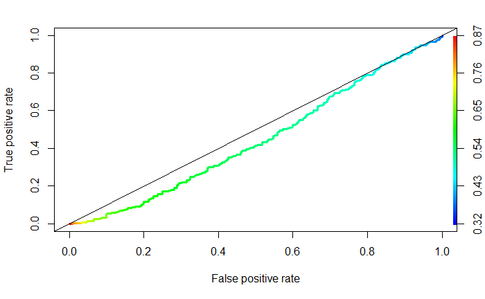

```r
pred.rocr2 <- predict(glm_ab2, newdata=test_ab, type="response")
f.pred2 <- prediction(pred.rocr2, test_ab$Sex)
f.perf2 <- performance(f.pred2, "tpr", "fpr")
plot(f.perf2, colorize=T, lwd=3)
abline(0,1)
```

```r
auc2 <- performance(f.pred2, measure = "auc")
cat(paste("The area under curve (AUC) for this model is ", round(auc2@y.values[[1]], 3)))
```

```
The area under curve (AUC) for this model is  0.445
```

Compared to the model1 with all the predictors the rpart decision tree and the model with two predictors has a higher area under the curve but the curve lies below the 50% probability line which tell us that model is not so good. Usually area under the curve should be close to 1 for the predictions to be accurate.

### problem 2.3

```r
url_mushroom <- "https://archive.ics.uci.edu/ml/machine-learning-databases/mushroom/agaricus-lepiota.data"
df_mushroom <- read.csv(url_mushroom,sep = ",",header = F)
head(df_mushroom)
```

|  | V1 | V2 | V3 | V4 | V5 | V6 | V7 | V8 | V9 | V10 | V11 | V12 | V13 | V14 | V15 | V16 | V17 | V18 | V19 | V20 | V21 | V22 | V23 |
| --- | --- | --- | --- | --- | --- | --- | --- | --- | --- | --- | --- | --- | --- | --- | --- | --- | --- | --- | --- | --- | --- | --- | --- |
| 1 | p | x | s | n | t | p | f | c | n | k | e | e | s | s | w | w | p | w | o | p | k | s | u |
| 2 | e | x | s | y | t | a | f | c | b | k | e | c | s | s | w | w | p | w | o | p | n | n | g |
| 3 | e | b | s | w | t | l | f | c | b | n | e | c | s | s | w | w | p | w | o | p | n | n | m |
| 4 | p | x | y | w | t | p | f | c | n | n | e | e | s | s | w | w | p | w | o | p | k | s | u |
| 5 | e | x | s | g | f | n | f | w | b | k | t | e | s | s | w | w | p | w | o | e | n | a | g |
| 6 | e | x | y | y | t | a | f | c | b | n | e | c | s | s | w | w | p | w | o | p | k | n | g |

```r
names(df_mushroom) <- c('Edible_Poison','Cap_shape','cap_surface','cap_color','bruises','odor','gill_attachment','gill_spacing','gill_size','gill_color','stalk_shape','stalk_root','stalk_surface_above_ring','stalk_surface_below_ring','stalk_color_above_ring','stalk_color_below_ring','veil_type','veil_color','ring_number','ring_type','spore_print_color','population','habitat')
head(df_mushroom)
```

|  | Edible_Poison | Cap_shape | cap_surface | cap_color | bruises | odor | gill_attachment | gill_spacing | gill_size | gill_color | stalk_shape | stalk_root | stalk_surface_above_ring | stalk_surface_below_ring | stalk_color_above_ring | stalk_color_below_ring | veil_type | veil_color | ring_number | ring_type | spore_print_color | population | habitat |
| --- | --- | --- | --- | --- | --- | --- | --- | --- | --- | --- | --- | --- | --- | --- | --- | --- | --- | --- | --- | --- | --- | --- | --- |
| 1 | p | x | s | n | t | p | f | c | n | k | e | e | s | s | w | w | p | w | o | p | k | s | u |
| 2 | e | x | s | y | t | a | f | c | b | k | e | c | s | s | w | w | p | w | o | p | n | n | g |
| 3 | e | b | s | w | t | l | f | c | b | n | e | c | s | s | w | w | p | w | o | p | n | n | m |
| 4 | p | x | y | w | t | p | f | c | n | n | e | e | s | s | w | w | p | w | o | p | k | s | u |
| 5 | e | x | s | g | f | n | f | w | b | k | t | e | s | s | w | w | p | w | o | e | n | a | g |
| 6 | e | x | y | y | t | a | f | c | b | n | e | c | s | s | w | w | p | w | o | p | k | n | g |

```r
sum(df_mushroom$stalk_root == "?")
```

```
[1] 2480
```

```r
index_nb <- sample(1:nrow(df_mushroom), size=0.2*nrow(df_mushroom))
test_nb <- df_mushroom[index_nb, ]
train_nb <- df_mushroom[-index_nb, ]
NaiveBayes_Classifier <- naiveBayes(x=train_nb[-1],y=train_nb$Edible_Poison)
summary(NaiveBayes_Classifier)
```

```
        Length Class  Mode
apriori  2     table  numeric
tables  22     -none- list
levels   2     -none- character
call     3     -none- call
```

```r
predictor_nb <- predict(NaiveBayes_Classifier, newdata = test_nb[-1])
head(predictor_nb)
```

```
[1] e e e e e p
Levels: e p
```

```r
head(test_nb$Edible_Poison)
```

```
[1] e e e e p p
Levels: e p
```

```r
table(predictor_nb,test_nb$Edible_Poison)
```

```
predictor_nb   e   p
           e 820 104
           p   7 693
```

```r
cm_nb <- confusionMatrix(predictor_nb,test_nb$Edible_Poison)
cm_nb
```

```
Confusion Matrix and Statistics

          Reference
Prediction   e   p
         e 820 104
         p   7 693

               Accuracy : 0.9317
                 95% CI : (0.9183, 0.9434)
    No Information Rate : 0.5092
    P-Value [Acc > NIR] : < 2.2e-16

                  Kappa : 0.863
 Mcnemar's Test P-Value : < 2.2e-16

            Sensitivity : 0.9915
            Specificity : 0.8695
         Pos Pred Value : 0.8874
         Neg Pred Value : 0.9900
             Prevalence : 0.5092
         Detection Rate : 0.5049
   Detection Prevalence : 0.5690
      Balanced Accuracy : 0.9305

       'Positive' Class : e
```

Number of false positives observed is 104 and the accuracy of the model prediction is 0.9317.

Predicting the response value of the train dataset using the model obtained from train dataset.

```r
predictor_nb_train <- predict(NaiveBayes_Classifier, newdata = train_nb[-1])
table(predictor_nb_train,train_nb$Edible_Poison)
```

```
predictor_nb_train    e    p
                 e 3357  358
                 p   24 2761
```

```r
cm_nb_train <- confusionMatrix(predictor_nb_train,train_nb$Edible_Poison)
cm_nb_train
```

```
Confusion Matrix and Statistics

          Reference
Prediction    e    p
         e 3357  358
         p   24 2761

               Accuracy : 0.9412
                 95% CI : (0.9352, 0.9468)
    No Information Rate : 0.5202
    P-Value [Acc > NIR] : < 2.2e-16

                  Kappa : 0.8818
 Mcnemar's Test P-Value : < 2.2e-16

            Sensitivity : 0.9929
            Specificity : 0.8852
         Pos Pred Value : 0.9036
         Neg Pred Value : 0.9914
             Prevalence : 0.5202
         Detection Rate : 0.5165
   Detection Prevalence : 0.5715
      Balanced Accuracy : 0.9391

       'Positive' Class : e
```

Accuracy for the classifier on the train and the test dataset almost the same (0.9317,0.9412).

removing rows where ? is present and again constructing the model

```r
dim(df_mushroom)
```

```
[1] 8124   23
```

```r
index_neg <- which(df_mushroom$stalk_root == "?")
new_df_mushroom <- df_mushroom[-index_neg,]
index_nb_n <- sample(1:nrow(new_df_mushroom), size=0.2*nrow(new_df_mushroom))
test_nb_n <- new_df_mushroom[index_nb_n, ]
train_nb_n <- new_df_mushroom[-index_nb_n, ]
NaiveBayes_Classifier_n <- naiveBayes(x=train_nb_n[-1],y=train_nb_n$Edible_Poison)
predictor_nb_n <- predict(NaiveBayes_Classifier_n, newdata = test_nb_n[-1])
cm_nb_n <- confusionMatrix(predictor_nb_n,test_nb_n$Edible_Poison)
cm_nb_n
```

```
Confusion Matrix and Statistics

          Reference
Prediction   e   p
         e 700  51
         p   1 376

               Accuracy : 0.9539
                 95% CI : (0.94, 0.9654)
    No Information Rate : 0.6215
    P-Value [Acc > NIR] : < 2.2e-16

                  Kappa : 0.8997
 Mcnemar's Test P-Value : 1.083e-11

            Sensitivity : 0.9986
            Specificity : 0.8806
         Pos Pred Value : 0.9321
         Neg Pred Value : 0.9973
             Prevalence : 0.6215
         Detection Rate : 0.6206
   Detection Prevalence : 0.6658
      Balanced Accuracy : 0.9396

       'Positive' Class : e
```

```r
head(predictor_nb_n)
```

```
[1] e e e p e e
Levels: e p
```

```r
head(test_nb_n$Edible_Poison)
```

```
[1] e e p p e p
Levels: e p
```

```r
table(predictor_nb_n,test_nb_n$Edible_Poison)
```

```
predictor_nb_n   e   p
             e 700  51
             p   1 376
```

The number of false positives after the rows containing ? values removed are 51.

Accuracy of the classifier after the removal of the rows containing ? is slightly (1-2%) higher than the classifier containing all the observations.